# R Notebook

### Library

```r
library("forecast")
```

```r
library("graphics")
library("TTR")
library("TSA")
library(dplyr)
library(forecast)
library(lmtest)
library(orcutt)
library(HoRM)
library(corrplot)
library(dLagM)
library(dynlm)
library(MLmetrics)
library(ggplot2)
library(tsibble)
library(tseries)
library(MASS)
library(aTSA)
```

### Input data

```r
dataziq <- read.csv("https://raw.githubusercontent.com/Raziqizzan03/MPDW/main/data/Pertemuan1/data%20suhu%20mekkah.csv")
dataziq
```

| periode | suhu.mekkah |
| --- | --- |
| 1 | 24.10 |
| 2 | 25.12 |
| 3 | 28.51 |
| 4 | 32.99 |
| 5 | 36.16 |
| 6 | 38.19 |
| 7 | 37.94 |
| 8 | 38.61 |
| 9 | 36.91 |
| 10 | 33.96 |

[output cut: 134 more lines]

```r
dataziq.ts <- ts(dataziq$suhu.mekkah)
```

### Membagi data menjadi data latih (80%) dan data uji (20%) dan jadikan time series

```r
dt.latih <- dataziq[1:115,2]
dt.uji <- dataziq[116:144,2]
dt.latih.ts <- ts(dt.latih, frequency = 12)
dt.uji.ts <- ts(dt.uji, frequency = 12)
```

# Eksplorasi data

### Membuat plot time series

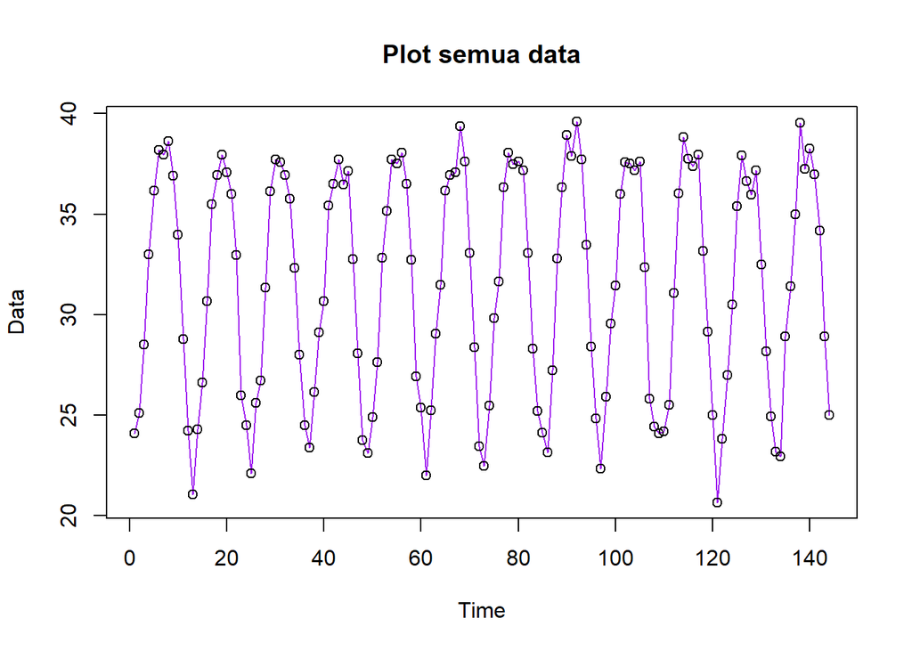

```r
# data full
ts.plot(dataziq.ts, col="purple",main="Plot semua data", type="o",xlab="Time",ylab="Data")
points(dataziq.ts)
```

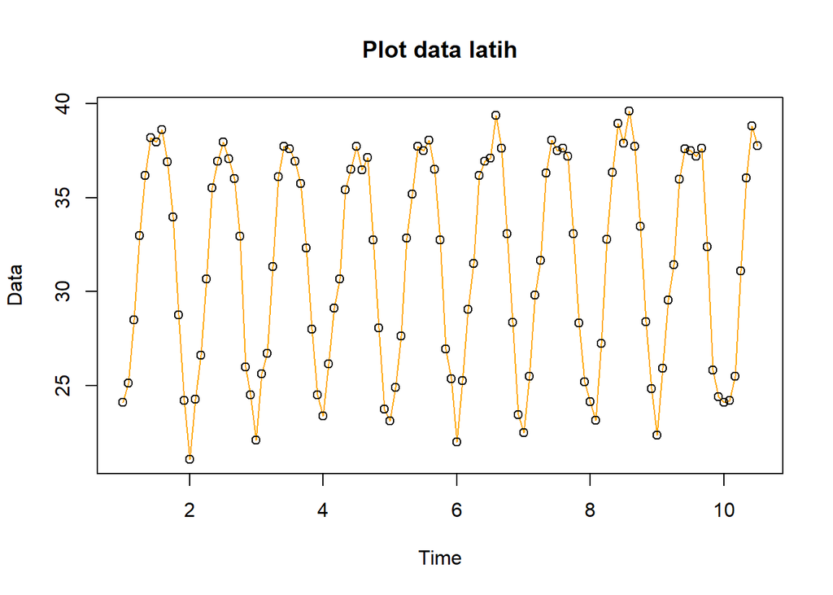

```r
# data latih
ts.plot(dt.latih.ts, col="orange",main="Plot data latih", type="o",xlab="Time",ylab="Data")
points(dt.latih.ts)
```

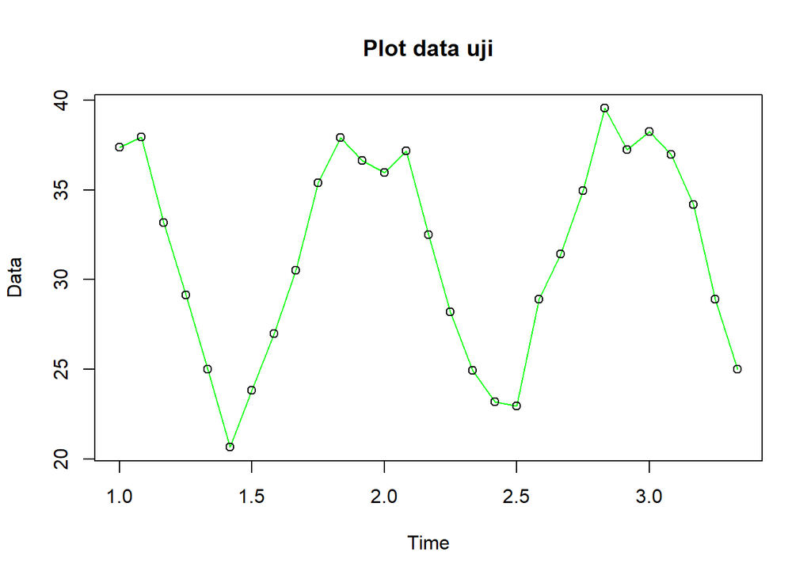

```r
# data uji
ts.plot(dt.uji.ts, col="green",main="Plot data uji", type="o",xlab="Time",ylab="Data")
points(dt.uji.ts)
```

dapat dilihat bahwwa data deret waktu pada suhu mekkah membentuk pola aditif musiman tanpa trend

# Pemulusan

## Single Moving Average

### Pemulusan dan peramalan

```r
data.sma <- SMA(dt.latih.ts,n=4)
data.sma
```

```
##        Jan     Feb     Mar     Apr     May     Jun     Jul     Aug     Sep
## 1       NA      NA      NA 27.6800 30.6950 33.9625 36.3200 37.7250 37.9125
## 2  27.0050 24.5875 24.0525 25.6675 29.2750 32.4350 35.2625 36.8625 36.9875
## 3  26.3850 24.5475 24.7350 26.4400 29.9475 32.9775 35.6900 37.0925 37.0025
## 4  27.0450 25.5050 25.7875 27.3300 30.3350 32.9200 35.0700 36.5250 36.9550
## 5  26.9325 24.9675 24.8550 27.1250 30.1350 33.3425 35.8125 37.1150 37.4500
## 6  26.7575 24.8875 25.4150 26.9450 30.4900 33.4125 35.4225 37.3950 37.7525
## 7  26.8425 24.9475 25.3075 27.3550 30.8150 33.9550 35.8750 37.3675 37.5850
## 8  27.6825 25.2000 24.9275 26.8250 29.8750 33.8225 36.4900 38.1900 38.5375
## 9  27.2625 25.3775 25.6625 27.3150 30.7225 33.6375 35.6275 37.0650 37.4750
## 10 26.6750 24.6325 24.5550 26.2225 29.2050 32.8600 35.9250
##        Oct     Nov     Dec
## 1  36.8550 34.5625 30.9650
## 2  35.9950 33.0050 29.8625
## 3  35.6475 33.2500 30.1375
## 4  36.0225 33.6125 30.4325
## 5  36.2000 33.5575 30.3850
## 6  36.7825 34.6025 30.6250
## 7  36.3450 34.0525 30.9475
## 8  37.1675 34.7950 31.1050
## 9  36.1725 33.2475 30.0550
## 10
```

```r
data.ramal<-c(NA,data.sma)
data.ramal
```

```
##   [1]      NA      NA      NA      NA 27.6800 30.6950 33.9625 36.3200 37.7250
##  [10] 37.9125 36.8550 34.5625 30.9650 27.0050 24.5875 24.0525 25.6675 29.2750
##  [19] 32.4350 35.2625 36.8625 36.9875 35.9950 33.0050 29.8625 26.3850 24.5475
##  [28] 24.7350 26.4400 29.9475 32.9775 35.6900 37.0925 37.0025 35.6475 33.2500
##  [37] 30.1375 27.0450 25.5050 25.7875 27.3300 30.3350 32.9200 35.0700 36.5250
##  [46] 36.9550 36.0225 33.6125 30.4325 26.9325 24.9675 24.8550 27.1250 30.1350
##  [55] 33.3425 35.8125 37.1150 37.4500 36.2000 33.5575 30.3850 26.7575 24.8875
##  [64] 25.4150 26.9450 30.4900 33.4125 35.4225 37.3950 37.7525 36.7825 34.6025
##  [73] 30.6250 26.8425 24.9475 25.3075 27.3550 30.8150 33.9550 35.8750 37.3675
##  [82] 37.5850 36.3450 34.0525 30.9475 27.6825 25.2000 24.9275 26.8250 29.8750
##  [91] 33.8225 36.4900 38.1900 38.5375 37.1675 34.7950 31.1050 27.2625 25.3775
## [100] 25.6625 27.3150 30.7225 33.6375 35.6275 37.0650 37.4750 36.1725 33.2475
## [109] 30.0550 26.6750 24.6325 24.5550 26.2225 29.2050 32.8600 35.9250
```

```r
# Forecasting 29 periode
data.gab<-cbind(aktual=c(dt.latih.ts,rep(NA,29)),pemulusan=c(data.sma,rep(NA,29)),ramalan=c(data.ramal,rep(data.ramal[length(data.ramal)],28)))
data.gab
```

```
##        aktual pemulusan ramalan
##   [1,]  24.10        NA      NA
##   [2,]  25.12        NA      NA
##   [3,]  28.51        NA      NA
##   [4,]  32.99   27.6800      NA
##   [5,]  36.16   30.6950 27.6800
##   [6,]  38.19   33.9625 30.6950
##   [7,]  37.94   36.3200 33.9625
##   [8,]  38.61   37.7250 36.3200
##   [9,]  36.91   37.9125 37.7250
##  [10,]  33.96   36.8550 37.9125
##  [11,]  28.77   34.5625 36.8550
##  [12,]  24.22   30.9650 34.5625
##  [13,]  21.07   27.0050 30.9650
##  [14,]  24.29   24.5875 27.0050
```

[output cut: 130 more lines]

### Plot forecasting

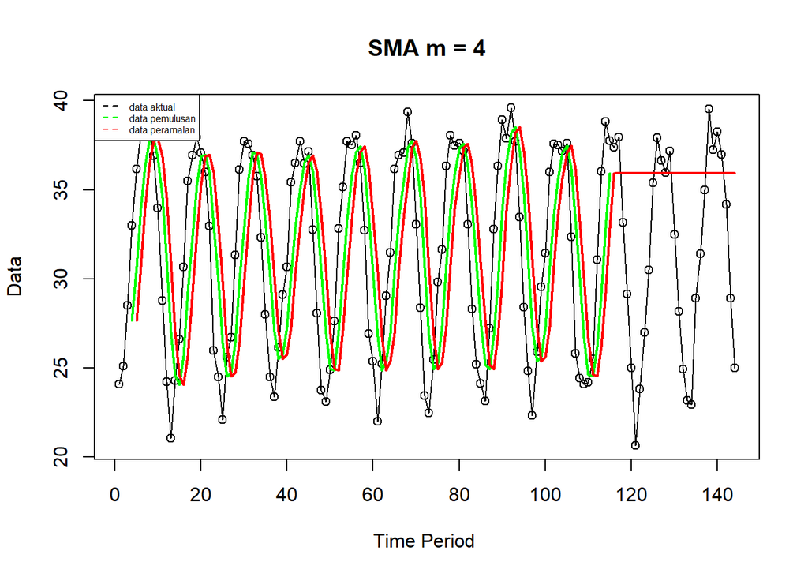

```r
ts.plot(dataziq.ts, xlab="Time Period ", ylab="Data", main= "SMA m = 4")
points(dataziq.ts)
lines(data.gab[,2],col="green",lwd=2)
lines(data.gab[,3],col="red",lwd=2)
legend("topleft",c("data aktual","data pemulusan","data peramalan"), lty=8, col=c("black","green","red"), cex=0.5)
```

### Akurasi data latih

```r
#Menghitung nilai keakuratan data latih
error_train.sma = dt.latih.ts-data.ramal[1:length(dt.latih.ts)]
SSE_train.sma = sum(error_train.sma[5:length(dt.latih.ts)]^2)
MSE_train.sma = mean(error_train.sma[5:length(dt.latih.ts)]^2)
MAPE_train.sma = mean(abs((error_train.sma[5:length(dt.latih.ts)]/dt.latih.ts[5:length(dt.latih.ts)])*100))

akurasi_train.sma <- matrix(c(SSE_train.sma, MSE_train.sma, MAPE_train.sma))
row.names(akurasi_train.sma)<- c("SSE", "MSE", "MAPE")
colnames(akurasi_train.sma) <- c("Akurasi m = 4")
akurasi_train.sma
```

```
##      Akurasi m = 4
## SSE     4407.87464
## MSE       39.71058
## MAPE      18.45565
```

### Akurasi data uji

```r
#Menghitung nilai keakuratan data uji
error_test.sma = dt.uji.ts-data.gab[116:144,3]
SSE_test.sma = sum(error_test.sma^2)
MSE_test.sma = mean(error_test.sma^2)
MAPE_test.sma = mean(abs((error_test.sma/dt.uji.ts*100)))

akurasi_test.sma <- matrix(c(SSE_test.sma, MSE_test.sma, MAPE_test.sma))
row.names(akurasi_test.sma)<- c("SSE", "MSE", "MAPE")
colnames(akurasi_test.sma) <- c("Akurasi m = 4")
akurasi_test.sma
```

```
##      Akurasi m = 4
## SSE     1460.63012
## MSE       50.36656
## MAPE      20.75195
```

## Double Moving Average (DMA)

### Pemulusan dan Peramalan

```r
dma <- SMA(data.sma, n = 4)
At <- 2*data.sma - dma
Bt <- 2/(4-1)*(data.sma - dma)
data.dma<- At+Bt

# Peramalan
data.ramal2<- c(NA, data.dma)

t = 1:29
f = c()

for (i in t) {
  f[i] = At[length(At)] + Bt[length(Bt)]*(i)
}

data.gab2 <- cbind(aktual = c(dt.latih.ts,rep(NA,29)), pemulusan1 = c(data.sma,rep(NA,29)),pemulusan2 = c(data.dma, rep(NA,29)),At = c(At, rep(NA,29)), Bt = c(Bt,rep(NA,29)),ramalan = c(data.ramal2, f[-1]))
data.gab2
```

```
##        aktual pemulusan1 pemulusan2       At          Bt   ramalan
##   [1,]  24.10         NA         NA       NA          NA        NA
##   [2,]  25.12         NA         NA       NA          NA        NA
##   [3,]  28.51         NA         NA       NA          NA        NA
##   [4,]  32.99    27.6800         NA       NA          NA        NA
##   [5,]  36.16    30.6950         NA       NA          NA        NA
##   [6,]  38.19    33.9625         NA       NA          NA        NA
##   [7,]  37.94    36.3200   43.24604 40.47563  2.77041667        NA
##   [8,]  38.61    37.7250   42.80729 40.77437  2.03291667  43.24604
##   [9,]  36.91    37.9125   40.30000 39.34500  0.95500000  42.80729
##  [10,]  33.96    36.8550   36.27479 36.50688 -0.23208333  40.30000
##  [11,]  28.77    34.5625   30.89375 32.36125 -1.46750000  36.27479
##  [12,]  24.22    30.9650   24.11708 26.85625 -2.73916667  30.89375
##  [13,]  21.07    27.0050   18.10188 21.66313 -3.56125000  24.11708
##  [14,]  24.29    24.5875   16.76667 19.89500 -3.12833333  18.10188
```

[output cut: 130 more lines]

### Plot Forecasting

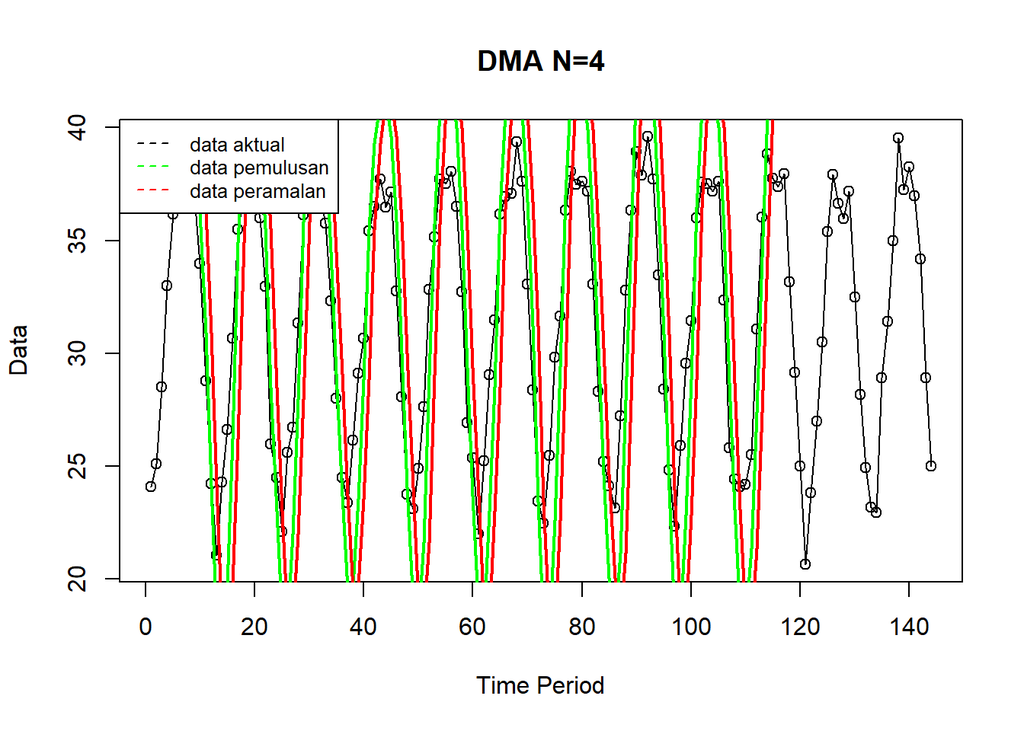

```r
ts.plot(dataziq.ts, xlab="Time Period", ylab="Data", main= "DMA N=4")
points(dataziq.ts)
lines(data.gab2[,3],col="green",lwd=2)
lines(data.gab2[,6],col="red",lwd=2)
legend("topleft",c("data aktual","data pemulusan","data peramalan"), lty=8, col=c("black","green","red"), cex=0.8)
```

### Akurasi data latih

```r
error_train.dma = dt.latih.ts-data.ramal2[1:length(dt.latih.ts)]
SSE_train.dma = sum(error_train.dma[8:length(dt.latih.ts)]^2)
MSE_train.dma = mean(error_train.dma[8:length(dt.latih.ts)]^2)
MAPE_train.dma = mean(abs((error_train.dma[8:length(dt.latih.ts)]/dt.latih.ts[8:length(dt.latih.ts)])*100))

akurasi_train.dma <- matrix(c(SSE_train.dma, MSE_train.dma, MAPE_train.dma))
row.names(akurasi_train.dma)<- c("SSE", "MSE", "MAPE")
colnames(akurasi_train.dma) <- c("Akurasi m = 4")
akurasi_train.dma
```

```
##      Akurasi m = 4
## SSE     4620.34145
## MSE       42.78094
## MAPE      19.28705
```

### Akurasi data uji

```r
error_test.dma = dt.uji.ts-data.gab2[116:144,6]
SSE_test.dma = sum(error_test.dma^2)
MSE_test.dma = mean(error_test.dma^2)
MAPE_test.dma = mean(abs((error_test.dma/dt.uji.ts*100)))

akurasi_test.dma <- matrix(c(SSE_test.dma, MSE_test.dma, MAPE_test.dma))
row.names(akurasi_test.dma)<- c("SSE", "MSE", "MAPE")
colnames(akurasi_test.dma) <- c("Akurasi m = 4")
akurasi_test.dma
```

```
##      Akurasi m = 4
## SSE    119036.1225
## MSE      4104.6939
## MAPE      192.0865
```

## Winter aditif

### Pemulusan dan Peramalan

```r
# optimum
winter.opt<- HoltWinters(dt.latih.ts, alpha= NULL,  beta = NULL, gamma = NULL, seasonal = "additive")
winter.opt
```

```
## Holt-Winters exponential smoothing with trend and additive seasonal component.
##
## Call:
## HoltWinters(x = dt.latih.ts, alpha = NULL, beta = NULL, gamma = NULL,     seasonal = "additive")
##
## Smoothing parameters:
##  alpha: 0.1347328
##  beta : 0.07756776
##  gamma: 0.2846425
##
## Coefficients:
##            [,1]
## a   31.11710557
## b   -0.02136399
## s1   6.51612115
## s2   5.70991374
## s3   1.42323689
## s4  -3.92052769
## s5  -6.82342932
## s6  -8.37750095
## s7  -6.64513911
## s8  -3.69226249
## s9   0.21277882
## s10  4.66285490
## s11  6.66189996
## s12  6.18527997
```

```r
winter.opt$fitted
```

```
##            xhat    level         trend      season
## Jan  2 21.75672 32.02042 -0.1025480769 -10.1611458
## Feb  2 24.83822 31.82534 -0.1097249626  -6.8773958
## Mar  2 27.09057 31.64176 -0.1154544056  -4.4357292
## Apr  2 31.03783 31.46425 -0.1202678102  -0.3061458
## May  2 35.84353 31.29577 -0.1240075009   4.6717708
## Jun  2 37.20381 31.12548 -0.1275977147   6.2059375
## Jul  2 36.83480 30.96099 -0.1304593328   6.0042708
## Aug  2 37.69563 30.97943 -0.1189089435   6.8351042
## Sep  2 35.90026 30.77758 -0.1253428291   5.2480208
## Oct  2 33.01398 30.66567 -0.1243004231   2.4726042
## Nov  2 27.81559 30.53410 -0.1248645490  -2.5936458
## Dec  2 22.95423 30.16192 -0.1440481702  -7.0636458
## Jan  3 19.76942 30.22749 -0.1277889274 -10.3302800
## Feb  3 23.29640 30.41236 -0.1035367186  -7.0124188
## Mar  3 25.99202 30.62054 -0.0793574868  -4.5491643
## Apr  3 30.17469 30.64061 -0.0716448793  -0.3942773
## May  3 35.25222 30.72462 -0.0595708171   4.5871620
## Jun  3 36.86997 30.78197 -0.0505016746   6.1384991
## Jul  3 37.08231 30.84735 -0.0415135730   6.2764732
## Aug  3 37.52006 30.87289 -0.0363122030   6.6834799
## Sep  3 35.98864 30.75842 -0.0423743171   5.2725867
## Oct  3 33.09979 30.68524 -0.0447637680   2.4593097
## Nov  3 27.43531 30.53407 -0.0530178008  -3.0457369
## Dec  3 23.82809 30.55579 -0.0472208308  -6.6804722
## Jan  4 20.79870 30.59775 -0.0403032937  -9.7587400
## Feb  4 24.45075 30.90658 -0.0132218472  -6.4425986
## Mar  4 26.75943 31.12230  0.0045368308  -4.3674051
## Apr  4 31.36435 31.44488  0.0292069699  -0.1097338
## May  4 36.20192 31.37919  0.0218458225   4.8008901
## Jun  4 37.65822 31.29434  0.0135694870   6.3503174
## Jul  4 37.55092 31.15051  0.0013604841   6.3990514
## Aug  4 37.71839 31.17465  0.0031275341   6.5406170
## Sep  4 36.21738 31.01092 -0.0098148153   5.2162757
## Oct  4 33.38858 31.12407 -0.0002771453   2.2647909
## Nov  4 28.12313 31.03910 -0.0068464073  -2.9091225
## Dec  4 24.50170 31.02644 -0.0072971723  -6.5174500
## Jan  5 21.78364 30.91921 -0.0150485766  -9.1205248
## Feb  5 25.06050 31.08557 -0.0009778908  -6.0240885
## Mar  5 27.27429 31.06296 -0.0026552491  -3.7860159
```

[output cut: 49 more lines]

```
## May  9 36.56221 31.94586  0.0148777314   4.6014697
## Jun  9 38.28414 31.88230  0.0087931185   6.3930499
## Jul  9 37.89589 31.79622  0.0014342169   6.0982351
## Aug  9 38.60856 31.74566 -0.0025986668   6.8655018
## Sep  9 37.12170 31.55194 -0.0174239697   5.5871858
## Oct  9 33.22268 31.60165 -0.0122162446   1.6332442
## Nov  9 28.09589 31.47455 -0.0211275046  -3.3575318
## Dec  9 24.23026 31.14544 -0.0450171604  -6.8701609
## Jan 10 22.24975 31.12598 -0.0430341948  -8.8332030
## Feb 10 24.81483 31.33224 -0.0236973489  -6.4937112
## Mar 10 28.15795 31.22570 -0.0301229045  -3.0376311
## Apr 10 30.96044 30.83747 -0.0579009389   0.1808683
## May 10 35.19855 30.79702 -0.0565468752   4.4580766
## Jun 10 37.02427 30.85250 -0.0478574973   6.2196262
## Jul 10 37.02069 31.04659 -0.0290904547   6.0031941
```

```r
xhat.opt <- winter.opt$fitted[,2]

# Peramalan
forecast.opt <- predict(winter.opt, n.ahead = 29)
forecast.opt
```

```
##         Jan      Feb      Mar      Apr      May      Jun      Jul      Aug
## 10                                                                37.61186
## 11 22.61142 24.32242 27.25393 31.13761 35.56632 37.54400 37.04602 37.35549
## 12 22.35505 24.06605 26.99756 30.88124 35.30995 37.28763 36.78965 37.09913
##         Sep      Oct      Nov      Dec
## 10 36.78429 32.47625 27.11112 24.18686
## 11 36.52792 32.21988 26.85475 23.93049
## 12 36.27156 31.96351 26.59839 23.67412
```

### Plot forecasting

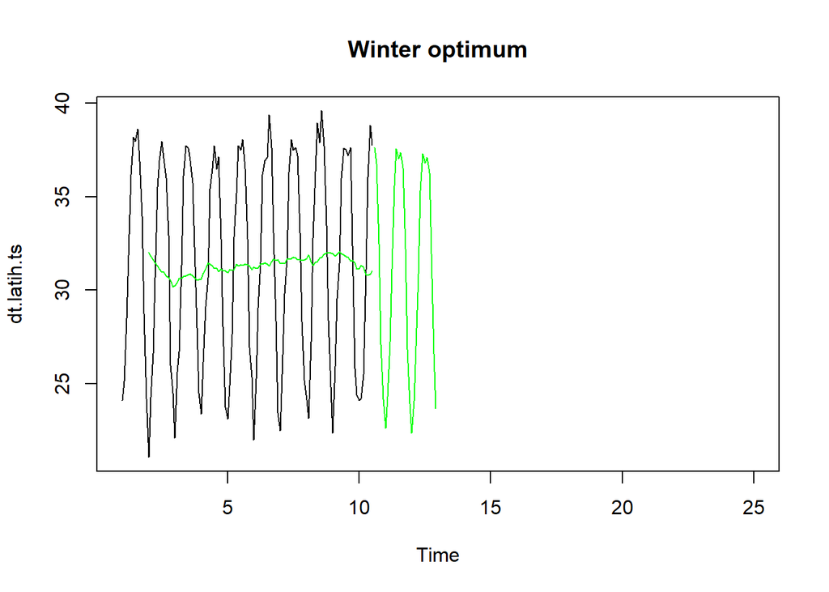

```r
plot(dt.latih.ts,main="Winter optimum",type="l",col="black",
     xlim=c(1,25),pch=20)
lines(xhat.opt,type="l",col="green")
lines(forecast.opt,type="l",col="green")
```

### Akurasi data latih

```r
SSE.opt<-winter.opt$SSE
MSE.opt<-winter.opt$SSE/length(dt.latih.ts)
RMSE.opt<-sqrt(MSE.opt)
akurasi.opt <- matrix(c(SSE.opt,MSE.opt,RMSE.opt))
row.names(akurasi.opt)<- c("SSE.opt", "MSE.opt", "RMSE.opt")
colnames(akurasi.opt) <- c("Akurasi")
akurasi.opt
```

```
##             Akurasi
## SSE.opt  116.780067
## MSE.opt    1.015479
## RMSE.opt   1.007710
```

### Akurasi data uji

```r
forecast.opt<-data.frame(forecast.opt)
dt.uji.ts <- data.frame(dt.uji.ts)
selisih.opt<-(forecast.opt)-(dt.uji.ts)
SSEuji.opt<-sum(selisih.opt^2)
MSEuji.opt<-SSEuji.opt/length(dt.uji.ts)
akurasi.opt <- matrix(c(SSE.opt,MSE.opt))
row.names(akurasi.opt)<- c("SSEuji.opt", "MSEuji.opt")
colnames(akurasi.opt) <- c("Akurasi")
akurasi.opt
```

[output not shown]

# Penanganan Autokorelasi

### Input data

```r
datasol <- read.csv("https://raw.githubusercontent.com/Raziqizzan03/MPDW/main/data/Pertemuan1/data%20tugas%203.csv")
View(datasol)
str(datasol)
```

```
## 'data.frame':    200 obs. of  10 variables:
##  $ open       : num  11.1 10.8 10.9 11.4 11.4 ...
##  $ High       : num  11.6 11.3 11 11.4 11.7 ...
##  $ low        : num  11.1 10.8 10.7 10.9 11.3 ...
##  $ close      : num  11.1 10.8 10.9 11.4 11.4 ...
##  $ volume     : int  4864322 5520210 7038886 7282602 7075356 5626819 5579050 9052957 4987451 5274492 ...
##  $ close.t.1. : num  NA 11.1 10.8 10.9 11.4 ...
##  $ open.t.1.  : num  NA 11.1 10.8 10.9 11.4 ...
##  $ high.t.1.  : num  NA 11.6 11.3 11 11.4 ...
##  $ low.t.1.   : num  NA 11.1 10.8 10.7 10.9 ...
##  $ volume.t.1.: int  NA 4864322 5520210 7038886 7282602 7075356 5626819 5579050 9052957 4987451 ...
```

```r
# Peubah yang digunakan
high <- datasol$High
low <- datasol$low
close <- datasol$close
Volume <- datasol$volume
Open <- datasol$open
```

### Mengubah data menjadi data deret waktu

```r
high.ts <- ts(high)
low.ts <- ts(low)
close.ts <- ts(close)
open.ts <- ts(Open)
volume.ts <- ts(Volume)
```

### Pembuatan regresi time series

### Pembuatan model awal

```r
model1 <- lm(Volume~high+low)
summary(model1)
```

```
##
## Call:
## lm(formula = Volume ~ high + low)
##
## Residuals:
##       Min        1Q    Median        3Q       Max
## -13894618  -5097724  -2745142    541551  51971867
##
## Coefficients:
##              Estimate Std. Error t value Pr(>|t|)
## (Intercept) -36129309   13400383  -2.696  0.00763 **
## high         16558970    4992203   3.317  0.00108 **
## low         -13398593    4531796  -2.957  0.00349 **
## ---
## Signif. codes:  0 '***' 0.001 '**' 0.01 '*' 0.05 '.' 0.1 ' ' 1
##
## Residual standard error: 9333000 on 196 degrees of freedom
##   (1 observation deleted due to missingness)
## Multiple R-squared:  0.06787,    Adjusted R-squared:  0.05836
## F-statistic: 7.135 on 2 and 196 DF,  p-value: 0.00102
```

Model yang dihasilkan adalah
$$y_i=-36129324+
16558983x1_t+-13398606x2_t$$
Berdasarkan ringkasan model dapat diketahui bahwa hasil uji F memiliki *p-value* < $\alpha$ (5%). Artinya, minimal terdapat satu variabel yang berpengaruh nyata terhadap model. Hasil uji-t parsial parameter regresi, yaitu koefisien regresi juga menunjukkan hal yang sama, yaitu memiliki *p-value* < $\alpha$ (5%) sehingga nyata dalam taraf 5%. Selanjutnya dapat dilihat juga nilai $R^2=0.06787$. Artinya, sebesar 6% keragaman nilai volume dapat dijelaskan oleh peubah high dan low. Namun, kita perlu melakukan uji terhadap sisaannya seperti berikut ini.

### plot asumsi

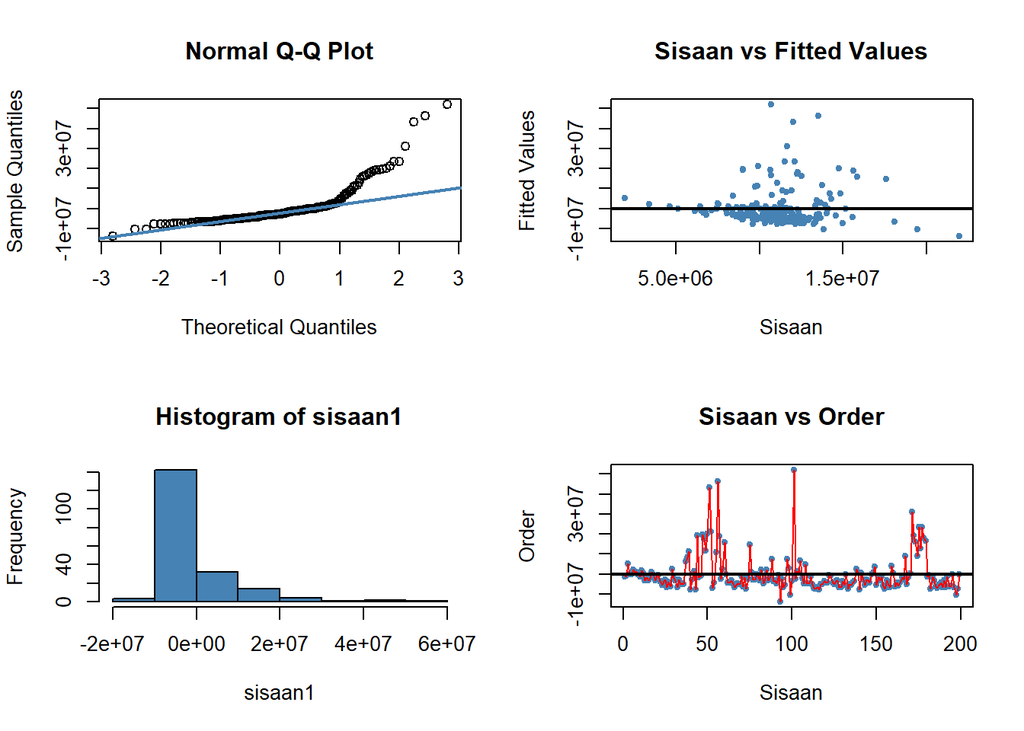

```r
#sisaan dan fitted value
sisaan1<- residuals(model1)
fitValue1<- predict(model1)

#Diagnostik dengan eksploratif
par(mfrow = c(2,2))
qqnorm(sisaan1)
qqline(sisaan1, col = "steelblue", lwd = 2)
plot(fitValue1, sisaan1, col = "steelblue", pch = 20, xlab = "Sisaan", ylab = "Fitted Values", main = "Sisaan vs Fitted Values")
abline(a = 0, b = 0, lwd = 2)
hist(sisaan1, col = "steelblue")
plot(seq(1,199,1), sisaan1, col = "steelblue", pch = 20, xlab = "Sisaan", ylab = "Order", main = "Sisaan vs Order")
lines(seq(1,199,1), sisaan1, col = "red")
abline(a = 0, b = 0, lwd = 2)
```

Dua plot di samping kiri digunakan untuk melihat apakah sisaan menyebar normal. Normal Q-Q Plot di atas menunjukkan bahwa sisaan cenderung tidak menyebar normal, dan histogram dari sisaan menunjukkan demikian. Selanjutnya, dua plot di samping kanan digunakan untuk melihat autokorelasi. Plot Sisaan vs *Fitted Value* dan Plot Sisaan vs *Order* menunjukkan adanya pola pada sisaan. Untuk lebih lanjut akan digunakan uji formal melihat normalitas sisaan dan plot ACF dan PACF untuk melihat apakah ada autokorelasi atau tidak.

### Uji formal Normalitas

```r
#H0: sisaan mengikuti sebaran normal
#H1: sisaan tidak mengikuti sebaran normal
ks.test(sisaan1, "pnorm", mean=mean(sisaan1), sd=sd(sisaan1))
```

```
##
##  Asymptotic one-sample Kolmogorov-Smirnov test
##
## data:  sisaan1
## D = 0.2401, p-value = 2.172e-10
## alternative hypothesis: two-sided
```

Berdasarkan uji formal Kolmogorov-Smirnov didapatkan nilai *p-value* < $\alpha$ (5%). Artinya, belum cukup bukti untuk menyatakan sisaan berdistribusi normal.

### Transformasi karna data tidak normal (1/x dan 1/y)

```r
Volumetrans <- 1/(Volume)
hightrans <- 1/(high)
lowtrans <- 1/(low)
# Model transformasi
modeltrans <- lm(Volumetrans~hightrans+lowtrans)
summary(modeltrans)
```

```
##
## Call:
## lm(formula = Volumetrans ~ hightrans + lowtrans)
##
## Residuals:
##        Min         1Q     Median         3Q        Max
## -1.210e-07 -4.025e-08 -2.120e-09  3.496e-08  3.756e-07
##
## Coefficients:
##               Estimate Std. Error t value Pr(>|t|)
## (Intercept) -2.296e-07  8.848e-08  -2.595   0.0102 *
## hightrans    2.662e-05  6.023e-06   4.420 1.63e-05 ***
## lowtrans    -2.118e-05  5.199e-06  -4.074 6.70e-05 ***
## ---
## Signif. codes:  0 '***' 0.001 '**' 0.01 '*' 0.05 '.' 0.1 ' ' 1
##
## Residual standard error: 6.522e-08 on 196 degrees of freedom
##   (1 observation deleted due to missingness)
## Multiple R-squared:  0.1021, Adjusted R-squared:  0.0929
## F-statistic: 11.14 on 2 and 196 DF,  p-value: 2.618e-05
```

Model transforasi yang dihasilkan adalah
$$y_i=-2.296e-07+
2.662e-05x1_t+-2.118e-05x2_t$$
Berdasarkan ringkasan model dapat diketahui bahwa hasil uji F memiliki *p-value* < $\alpha$ (5%). Artinya, minimal terdapat satu variabel yang berpengaruh nyata terhadap model. Hasil uji-t parsial parameter regresi, yaitu koefisien regresi juga menunjukkan hal yang sama, yaitu memiliki *p-value* < $\alpha$ (5%) sehingga nyata dalam taraf 5%. Selanjutnya dapat dilihat juga nilai $R^2=0.1021$. Artinya, sebesar 10% keragaman nilai volume dapat dijelaskan oleh peubah high dan low. Namun, kita perlu melakukan uji terhadap sisaannya seperti berikut ini.

### cek ulang normalitas

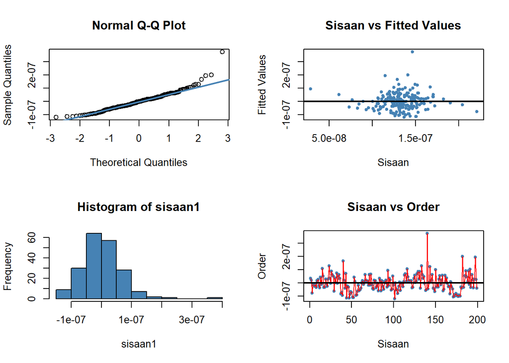

```r
#sisaan dan fitted value
sisaan1<- residuals(modeltrans)
fitValue1<- predict(modeltrans)

#Diagnostik dengan eksploratif
par(mfrow = c(2,2))
qqnorm(sisaan1)
qqline(sisaan1, col = "steelblue", lwd = 2)
plot(fitValue1, sisaan1, col = "steelblue", pch = 20, xlab = "Sisaan", ylab = "Fitted Values", main = "Sisaan vs Fitted Values")
abline(a = 0, b = 0, lwd = 2)
hist(sisaan1, col = "steelblue")
plot(seq(1,199,1), sisaan1, col = "steelblue", pch = 20, xlab = "Sisaan", ylab = "Order", main = "Sisaan vs Order")
lines(seq(1,199,1), sisaan1, col = "red")
abline(a = 0, b = 0, lwd = 2)
```

```r
# Uji Formal normalitas
#H0: sisaan mengikuti sebaran normal
#H1: sisaan tidak mengikuti sebaran normal
ks.test(sisaan1, "pnorm", mean=mean(sisaan1), sd=sd(sisaan1))
```

```
##
##  Asymptotic one-sample Kolmogorov-Smirnov test
##
## data:  sisaan1
## D = 0.063155, p-value = 0.4054
## alternative hypothesis: two-sided
```

Dua plot di samping kiri digunakan untuk melihat apakah sisaan menyebar normal. Normal Q-Q Plot di atas menunjukkan bahwa sisaan cenderung menyebar normal, dan histogram dari sisaan menunjukkan demikian. Berdasarkan uji formal Kolmogorov-Smirnov didapatkan nilai *p-value* > $\alpha$ (5%). Artinya, cukup bukti untuk menyatakan sisaan berdistribusi normal.

### ACF dan PACF identifikasi autokorelasi

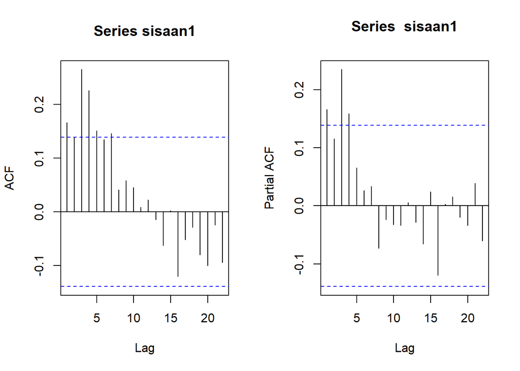

```r
par(mfrow = c(1,2))
acf(sisaan1)
pacf(sisaan1)
```

Berdasarkan plot ACF dan PACF, terlihat terdapat data yang berada diluar rentang batas sehingga ada yang signifikan. Namun, untuk lebih memastikan akan dilakukan uji formal dengan uji Durbin Watson.

### Uji formal autokorelasi

```r
#H0: tidak ada autokorelasi
#H1: ada autokorelasi
dwtest(modeltrans)
```

```
##
##  Durbin-Watson test
##
## data:  modeltrans
## DW = 1.6646, p-value = 0.006793
## alternative hypothesis: true autocorrelation is greater than 0
```

Berdasarkan hasil DW Test, didapatkan nilai $DW = 1.6646$ dan *p-value* = $0.006793$. Dengan nilai *p-value* < 0.05 dapat disimpulkan bahwa tolak H0, cukup bukti mengatakan adanya autokorelasi. Oleh karena itu, diperlukan penangan autokorelasi. Penanganan yang akan digunakan menggunakan dua metode, yaitu Cochrane-Orcutt dan Hildret-Lu.

### Metode Cochrane-Orcutt

```r
#Penanganan Autokorelasi Cochrane-Orcutt
modelCO1<-cochrane.orcutt(modeltrans)
modelCO1
```

```
## Cochrane-orcutt estimation for first order autocorrelation
##
## Call:
## lm(formula = Volumetrans ~ hightrans + lowtrans)
##
##  number of interaction: 6
##  rho 0.173819
##
## Durbin-Watson statistic
## (original):    1.66458 , p-value: 6.793e-03
## (transformed): 2.03818 , p-value: 5.794e-01
##
##  coefficients:
## (Intercept)   hightrans    lowtrans
##     0.0e+00     2.3e-05    -1.9e-05
```

```r
modelCO1$coefficients
```

```
##   (Intercept)     hightrans      lowtrans
## -1.916405e-07  2.339588e-05 -1.854018e-05
```

Hasil keluaran model setelah dilakukan penanganan adalah sebagai berikut.
$$y_i=-1.916405e-07+2.339589e-05x1_t+-1.854019e-05x2_t$$
Hasil juga menunjukkan bahwa nilai DW dan p-value meningkat menjadi $2.03818$ dan $0.579$. dengan nilai *p-value* > 0.05, artinya belum cukup bukti menyatakan bahwa sisaan terdapat autokorelasi pada taraf nyata 5%. Untuk nilai $ρ ̂$ optimum yang digunakan adalah $0.173819$. Nilai tersebut dapat diketahui dengan *syntax* berikut.

```r
#Rho optimum
rho1<- modelCO1$rho
rho1
```

```
## [1] 0.1738193
```

### Transformasi manual

```r
#Transformasi Manual
volume.trans<- Volumetrans[-1]-Volumetrans[-199]*rho1
high.trans<- hightrans[-1]-hightrans[-199]*rho1
low.trans<- lowtrans[-1]-lowtrans[-199]*rho1
modelCOmanual1<- lm(volume.trans~high.trans+low.trans)
summary(modelCOmanual1)
```

```
##
## Call:
## lm(formula = volume.trans ~ high.trans + low.trans)
##
## Residuals:
##        Min         1Q     Median         3Q        Max
## -1.244e-07 -4.176e-08 -6.260e-09  3.392e-08  3.863e-07
##
## Coefficients:
##               Estimate Std. Error t value Pr(>|t|)
## (Intercept) -1.583e-07  8.394e-08  -1.886 0.060760 .
## high.trans   2.340e-05  6.107e-06   3.831 0.000172 ***
## low.trans   -1.854e-05  5.271e-06  -3.517 0.000542 ***
## ---
## Signif. codes:  0 '***' 0.001 '**' 0.01 '*' 0.05 '.' 0.1 ' ' 1
##
## Residual standard error: 6.439e-08 on 195 degrees of freedom
##   (1 observation deleted due to missingness)
## Multiple R-squared:  0.07585,    Adjusted R-squared:  0.06637
## F-statistic: 8.002 on 2 and 195 DF,  p-value: 0.0004571
```

```r
#Mencari Penduga Koefisien Regresi setelah Transformasi ke Persamaan Awal
b0bintang1 <- modelCOmanual1$coefficients[1]
b0.1<- b0bintang1/(1-rho1)
b1.1 <- modelCOmanual1$coefficients[2]
b2.1 <- modelCOmanual1$coefficients[3]
b0.1
```

```
##   (Intercept)
## -1.916405e-07
```

```r
b1.1
```

```
##   high.trans
## 2.339588e-05
```

```r
b2.1
```

```
##     low.trans
## -1.854018e-05
```

### Metode Hildreth-Lu

```r
hildreth.lu.func<- function(r, model){
  x1 <- model.matrix(model)[,c(-1,-3)]
  x2 <- model.matrix(model)[,c(-1,-2)]
  y <- model.response(model.frame(model))
  n <- length(y)
  t <- 2:n
  y <- y[t]-r*y[t-1]
  x1 <- x1[t]-r*x1[t-1]
  x2 <- x2[t]-r*x2[t-1]

  return(lm(y~x1+x2))
}

#Pencariab rho yang meminimumkan SSE
r1 <- c(seq(0.1,0.9, by= 0.1))
tab1 <- data.frame("rho" = r1, "SSE" = sapply(r1, function(i){deviance(hildreth.lu.func(i, modeltrans))}))
tab1
```

| rho | SSE |
| --- | --- |
| 0.1 | 8.127715e-13 |
| 0.2 | 8.089693e-13 |
| 0.3 | 8.211647e-13 |
| 0.4 | 8.494666e-13 |
| 0.5 | 8.940324e-13 |
| 0.6 | 9.550241e-13 |
| 0.7 | 1.032561e-12 |
| 0.8 | 1.126689e-12 |
| 0.9 | 1.237486e-12 |

Pertama-tama akan dicari di mana kira-kira $ρ$ yang menghasilkan SSE minimum. Pada hasil di atas terlihat $ρ$ minimum ketika 0.2. Namun, hasil tersebut masih kurang teliti sehingga akan dicari kembali $ρ$ yang lebih optimum dengan ketelitian yang lebih. Jika sebelumnya jarak antar $ρ$ yang dicari adalah 0.1, kali ini jarak antar $ρ$ adalah 0.001 dan dilakukan pada selang 0.1 sampai dengan 0.4.

```r
rOpt1<- seq(0.1,0.4, by= 0.001)
tabOpt1 <- data.frame("rho" = rOpt1, "SSE" = sapply(rOpt1, function(i){deviance(hildreth.lu.func(i, modeltrans))}))
head(tabOpt1[order(tabOpt1$SSE),])
```

|  | rho | SSE |
| --- | --- | --- |
| 75 | 0.174 | 8.084217e-13 |
| 74 | 0.173 | 8.084222e-13 |
| 76 | 0.175 | 8.084228e-13 |
| 73 | 0.172 | 8.084243e-13 |
| 77 | 0.176 | 8.084255e-13 |
| 72 | 0.171 | 8.084280e-13 |

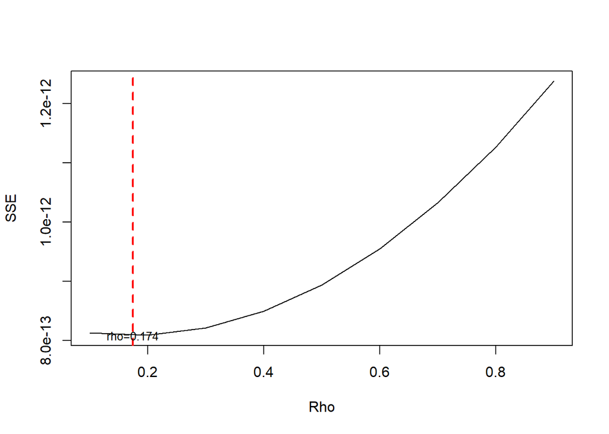

```r
#Grafik SSE optimum
par(mfrow = c(1,1))
plot(tab1$SSE ~ tab1$rho , type = "l", xlab = "Rho", ylab = "SSE")
abline(v = tabOpt1[tabOpt1$SSE==min(tabOpt1$SSE),"rho"], lty = 2, col="red",lwd=2)
text(x=0.174, y=8.084217e-13        , labels = "rho=0.174", cex = 0.8)
```

Perhitungan yang dilakukan aplikasi `R` menunjukkan bahwa nilai $ρ$ optimum, yaitu saat SSE terkecil terdapat pada nilai $ρ=0.174$. Hal tersebut juga ditunjukkan pada plot. Selanjutnya, model dapat didapatkan dengan mengevaluasi nilai $ρ$ ke dalam fungsi `hildreth.lu.func`, serta dilanjutkan dengan pengujian autokorelasi dengan uji Durbin-Watson. Namun, setelah pengecekan tersebut tidak lupa koefisien regresi tersebut digunakan untuk transformasi balik. Persamaan hasil transformasi itulah yang menjadi persamaan sesungguhnya.

```r
#Model terbaik
modelHL1 <- hildreth.lu.func(0.174, modeltrans)
summary(modelHL1)
```

```
##
## Call:
## lm(formula = y ~ x1 + x2)
##
## Residuals:
##        Min         1Q     Median         3Q        Max
## -1.244e-07 -4.176e-08 -6.260e-09  3.393e-08  3.863e-07
##
## Coefficients:
##               Estimate Std. Error t value Pr(>|t|)
## (Intercept) -1.583e-07  8.394e-08  -1.886 0.060843 .
## x1           2.339e-05  6.107e-06   3.830 0.000173 ***
## x2          -1.854e-05  5.271e-06  -3.517 0.000543 ***
## ---
## Signif. codes:  0 '***' 0.001 '**' 0.01 '*' 0.05 '.' 0.1 ' ' 1
##
## Residual standard error: 6.439e-08 on 195 degrees of freedom
## Multiple R-squared:  0.07582,    Adjusted R-squared:  0.06635
## F-statistic: 7.999 on 2 and 195 DF,  p-value: 0.0004582
```

```r
#Transformasi Balik
cat("y = ", coef(modelHL1)[1]/(1-0.174), "+", coef(modelHL1)[2],"x1","+", coef(modelHL1)[3],"x2", sep = "")
```

```
## y = -1.916084e-07+2.339269e-05x1+-1.85375e-05x2
```

Setelah dilakukan tranformasi balik, didapatkan model dengan metode Hildreth-Lu sebagai berikut.
$$y_i=-1.916083e-07+
2.339e-05x1_t+-1.854e-05x2_t$$

```r
#Deteksi autokorelasi
dwtest(modelHL1)
```

```
##
##  Durbin-Watson test
##
## data:  modelHL1
## DW = 2.0386, p-value = 0.5805
## alternative hypothesis: true autocorrelation is greater than 0
```

```r
dwtest(modelCOmanual1)
```

```
##
##  Durbin-Watson test
##
## data:  modelCOmanual1
## DW = 2.0382, p-value = 0.5794
## alternative hypothesis: true autocorrelation is greater than 0
```

Hasil uji Durbin-Watson juga menunjukkan bahwa *p-value* sebesar $0.5805$, di mana *p-value* > $\alpha=5%$. Artinya tak tolak $H_0$ atau belum cukup bukti menyatakan bahwa ada autokorelasi dalam data nilai volume dengan metode Hildreth-Lu pada taraf nyata 5%.

### Perbandingan keakuratan

```r
sseModelawal1 <- anova(modeltrans)$`Sum Sq`[c(-1,-2)]
sseModelCO1 <- anova(modelCOmanual1)$`Sum Sq`[c(-1,-2)]
sseModelHL1 <- anova(modelHL1)$`Sum Sq`[c(-1,-2)]
mseModelawal1 <- sseModelawal1/length(Volumetrans)
mseModelCO1 <- sseModelCO1/length(Volumetrans)
mseModelHL1 <- sseModelHL1/length(Volumetrans)
akurasi1 <- matrix(c(sseModelawal1,sseModelCO1,sseModelHL1,
                    mseModelawal1,mseModelCO1,mseModelHL1),nrow=2,ncol=3,byrow = T)
colnames(akurasi1) <- c("Model Awal", "Model Cochrane-Orcutt", "Model Hildreth-Lu")
row.names(akurasi1) <- c("SSE","MSE")
akurasi1
```

```
##      Model Awal Model Cochrane-Orcutt Model Hildreth-Lu
## SSE 8.33816e-13          8.084217e-13      8.084217e-13
## MSE 4.16908e-15          4.042108e-15      4.042109e-15
```

### Simpulan

Autokorelasi yang terdapat pada data Volume terjadi akibat adanya korelasi di antara unsur penyusunnya. Adanya autokorelasi menyebabkan model regresi kurang baik karena akan meingkatkan galatnya. Autokorelasi dapat dideteksi secara eksploratif melalui plot sisaan, ACF, dan PACF, serta dengan uji formal Durbin-Watson. Namun, autokorelasi tersebut dapat ditangani dengan metode Cochrane-Orcutt dan Hildreth-Lu. Kedua metode menghasilkan nilai SSE yang sama, artinya keduanya baik untuk digunakan

# CEK Kestasioneran data

### Input data

```r
dataSmekah<- read.csv("https://raw.githubusercontent.com/Raziqizzan03/MPDW/main/data/Pertemuan1/data%20suhu%20mekkah.csv")
```

### Ubah data ke ts

```r
dataSmekah.ts <- ts(dataSmekah$suhu.mekkah)
```

### Membuat plot time series

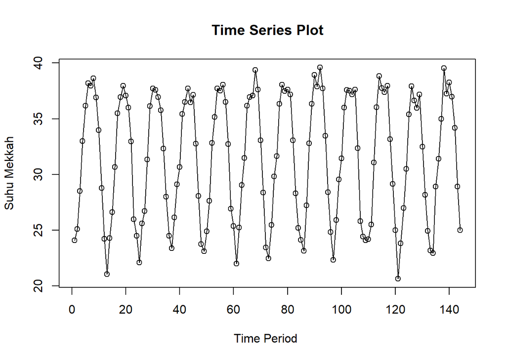

```r
ts.plot(dataSmekah.ts, xlab="Time Period ", ylab="Suhu Mekkah",
        main = "Time Series Plot")
points(dataSmekah.ts)
```

dalam plot terlihat bahwa data stasioner dalam rataan dan ragam

### Plot ACF

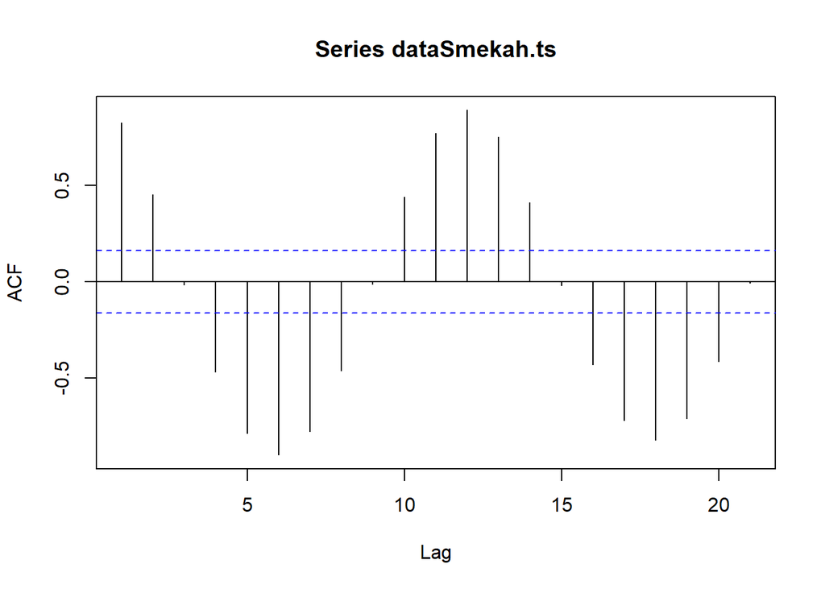

```r
acf(dataSmekah.ts)
```

Berdasarkan plot ACF, terlihat bahwa plot ACF pada data tersebut cenderung *tails off* dan membentuk gelombang sinus.

### Uji ADF

```r
tseries::adf.test(dataSmekah.ts)
```

```
##
##  Augmented Dickey-Fuller Test
##
## data:  dataSmekah.ts
## Dickey-Fuller = -11.127, Lag order = 5, p-value = 0.01
## alternative hypothesis: stationary
```

$H_0$ : Data tidak stasioner dalam rataan

$H_1$ : Data stasioner dalam rataan

Berdasarkan uji ADF tersebut, didapat *p-value* sebesar 0.01 yang lebih kecil dari taraf nyata 5% sehingga tolak $H_0$ dan menandakan bahwa data stasioner dalam rataan. Hal ini sesuai dengan hasil eksplorasi menggunakan plot time series dan plot ACF.

### Plot Box-Cox

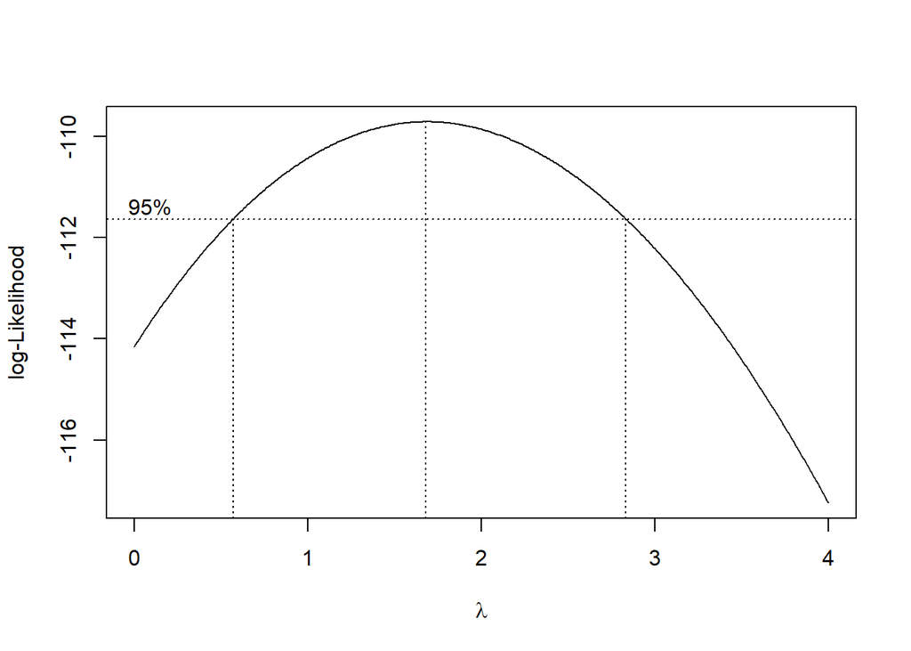

```r
index <- seq(1:144)
bc = boxcox(dataSmekah.ts~index, lambda = seq(0,4,by=0.01))
```

```r
#Nilai Rounded Lambda
lambda <- bc$x[which.max(bc$y)]
lambda
```

```
## [1] 1.68
```

```r
#SK
bc$x[bc$y > max(bc$y) - 1/2 * qchisq(.95,1)]
```

```
##   [1] 0.57 0.58 0.59 0.60 0.61 0.62 0.63 0.64 0.65 0.66 0.67 0.68 0.69 0.70 0.71
##  [16] 0.72 0.73 0.74 0.75 0.76 0.77 0.78 0.79 0.80 0.81 0.82 0.83 0.84 0.85 0.86
##  [31] 0.87 0.88 0.89 0.90 0.91 0.92 0.93 0.94 0.95 0.96 0.97 0.98 0.99 1.00 1.01
##  [46] 1.02 1.03 1.04 1.05 1.06 1.07 1.08 1.09 1.10 1.11 1.12 1.13 1.14 1.15 1.16
##  [61] 1.17 1.18 1.19 1.20 1.21 1.22 1.23 1.24 1.25 1.26 1.27 1.28 1.29 1.30 1.31
##  [76] 1.32 1.33 1.34 1.35 1.36 1.37 1.38 1.39 1.40 1.41 1.42 1.43 1.44 1.45 1.46
##  [91] 1.47 1.48 1.49 1.50 1.51 1.52 1.53 1.54 1.55 1.56 1.57 1.58 1.59 1.60 1.61
## [106] 1.62 1.63 1.64 1.65 1.66 1.67 1.68 1.69 1.70 1.71 1.72 1.73 1.74 1.75 1.76
## [121] 1.77 1.78 1.79 1.80 1.81 1.82 1.83 1.84 1.85 1.86 1.87 1.88 1.89 1.90 1.91
## [136] 1.92 1.93 1.94 1.95 1.96 1.97 1.98 1.99 2.00 2.01 2.02 2.03 2.04 2.05 2.06
## [151] 2.07 2.08 2.09 2.10 2.11 2.12 2.13 2.14 2.15 2.16 2.17 2.18 2.19 2.20 2.21
## [166] 2.22 2.23 2.24 2.25 2.26 2.27 2.28 2.29 2.30 2.31 2.32 2.33 2.34 2.35 2.36
## [181] 2.37 2.38 2.39 2.40 2.41 2.42 2.43 2.44 2.45 2.46 2.47 2.48 2.49 2.50 2.51
## [196] 2.52 2.53 2.54 2.55 2.56 2.57 2.58 2.59 2.60 2.61 2.62 2.63 2.64 2.65 2.66
## [211] 2.67 2.68 2.69 2.70 2.71 2.72 2.73 2.74 2.75 2.76 2.77 2.78 2.79 2.80 2.81
## [226] 2.82 2.83
```

Gambar di atas menunjukkan nilai *rounded value* ($\lambda$) optimum sebesar **1.68** dan pada selang kepercayaan 95% nilai memiliki batas bawah **0.57** dan batas atas **2.83**. Selang tersebut memuat nilai satu sehingga dapat dikatakan bahwa data bangkitan stasioner dalam ragam.

Kesimpulan: Maka data tersebut stasioner dalam rataan dan ragam

# Analisis seluruhnya

## Pembangkitan Data

Data yang akan dibangkitkan adalah data dengan model MA(2) sebagai berikut.

```r
set.seed(99)
ma2 <- arima.sim(list(order = c(0,0,2), ma = c(0.55,0.65)), n = 175)
```

Data kemudian dibagi menjadi data latih dan data uji. Pembagian kali ini dilakukan dengan proporsi / perbandingan, yaitu 80:20.

```r
ma2 <- ma2[-c(1:25)]
ma2.train <- ma2[1:120]
ma2.test <- ma2[121:150]
```

### Eksplorasi Data

Sebelum masuk dalam tahap pemodelan, dilakukan eksplorasi data dengan plot deret waktu untuk melihat pola data.

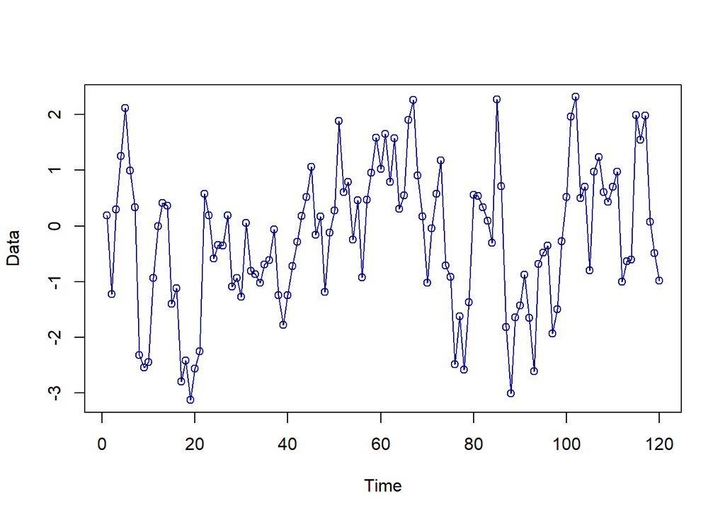

```r
#--PLOT TIME SERIES--#
plot(ma2.train,
     col = "navyblue",
     lwd = 1,
     type = "o",
     xlab = "Time",
     ylab = "Data")
```

Berdasarkan plot data deret waktu di atas, terlihat data cenderung stasioner dalam rataan dan ragam. Data stasioner dalam rataan karena menyebar/bergerak di sekitar nilai tengahnya (0) dan dikatakan stasioner dalam ragam karena memiliki lebar pita yang cenderung sama. Selain dengan plot data deret waktu, akan dilakukan pengecekan stasioneritas data dengan plot ACF dan uji ADF.

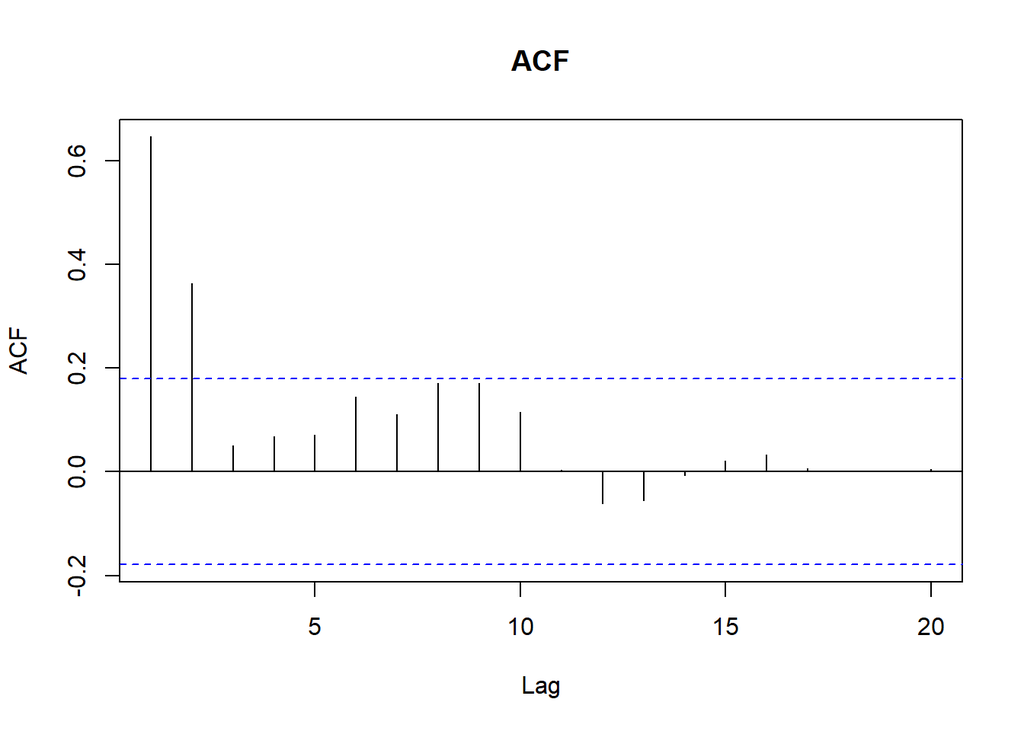

```r
#--CEK KESTASIONERAN---#
acf(ma2.train, main="ACF", lag.max=20)
```

Berdasarkan plot ACF di atas, dapat dilihat bahwa plot *cuts off* pada *lag* ke-2. Hal ini sesuai dengan proses pembangkitan model MA(2).

```r
adf.test(ma2.train)
```

```
## Augmented Dickey-Fuller Test
## alternative: stationary
##
## Type 1: no drift no trend
##      lag   ADF p.value
## [1,]   0 -4.91    0.01
## [2,]   1 -4.89    0.01
## [3,]   2 -5.65    0.01
## [4,]   3 -3.57    0.01
## [5,]   4 -3.43    0.01
## Type 2: with drift no trend
##      lag   ADF p.value
## [1,]   0 -4.99    0.01
## [2,]   1 -4.95    0.01
## [3,]   2 -5.78    0.01
## [4,]   3 -3.69    0.01
## [5,]   4 -3.59    0.01
## Type 3: with drift and trend
##      lag   ADF p.value
## [1,]   0 -5.10  0.0100
## [2,]   1 -5.04  0.0100
## [3,]   2 -6.02  0.0100
## [4,]   3 -3.99  0.0123
## [5,]   4 -3.96  0.0138
## ----
## Note: in fact, p.value = 0.01 means p.value <= 0.01
```

```r
#stasioner
```

$H_0$ : Data tidak stasioner dalam rataan

$H_1$ : Data stasioner dalam rataan

### Spesifikasi Model

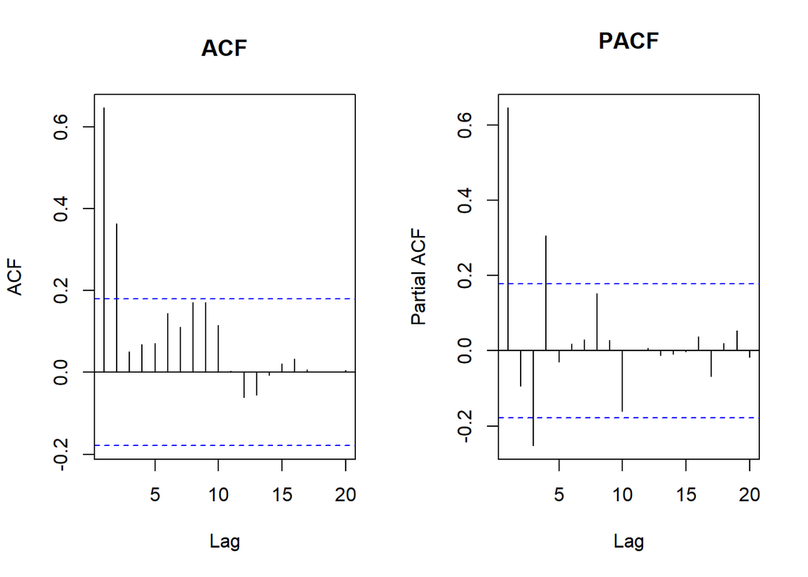

```r
#---SPESIFIKASI MODEL---#
par(mfrow = c(1,2))
acf(ma2.train, main="ACF", lag.max=20) #ARIMA(0,0,2)
pacf(ma2.train, main="PACF", lag.max=20) #ARIMA(1,0,0)
```

```r
par(mfrow = c(1,1))
```

```r
eacf(ma2.train)
```

```
## AR/MA
##   0 1 2 3 4 5 6 7 8 9 10 11 12 13
## 0 x x o o o o o o o o o  o  o  o
## 1 o x x o o o o o o o o  o  o  o
## 2 x x x o o o o o o o o  o  o  o
## 3 x x x o o o o o o o o  o  o  o
## 4 o o o x o o o o o o o  o  o  o
## 5 x o o x o o o o o o o  o  o  o
## 6 x o o o o o o o x o o  o  o  o
## 7 o o o o o x o o o o o  o  o  o
```

```r
#ARIMA(0,0,2) #ARIMA(1,0,3) #ARIMA(2,0,3) #ARIMA(3,0,3)
#Terdapat 5 model tentatif
```

Menggunakan plot EACF, dapat diambil beberapa model dengan melihat ujung segitiga yang terbentuk, antara lain ARIMA(0,0,2), ARIMA(1,0,3), ARIMA(2,0,3), dan ARIMA(3,0,3).